# Biostat 212a Homework 4

Due Mar. 12, 2024 @ 11:59PM

Author

Kathy Hoang and 506333118

Published

March 12, 2024

```r
#Clear Environment
rm(list=ls())
```

```r
#load libraries
library(GGally)
library(gtsummary)
library(ranger)
library(tidyverse)
library(tidymodels)
library(ISLR2)
library(yardstick)
library(recipes)
library(parsnip)
library(dials)
library(workflows)
library(rpart.plot)
library(vip)
```

## 1 ISL Exercise 8.4.3 (10pts)

Consider the Gini index, classification error, and entropy in a simple classification setting with two classes. Create a single plot that displays each of these quantities as a function of $\hat{p}_{m1}$. The x-axis should display $\hat{p}_{m1}$, ranging from 0 to 1, and the y-axis should display the value of the Gini index, classification error, and entropy. Hint: In a setting with two classes, $\hat{p}_{m1}$ = 1 − $\hat{p}_{m2}$. You could make this plot by hand, but it will be much easier to make in R.

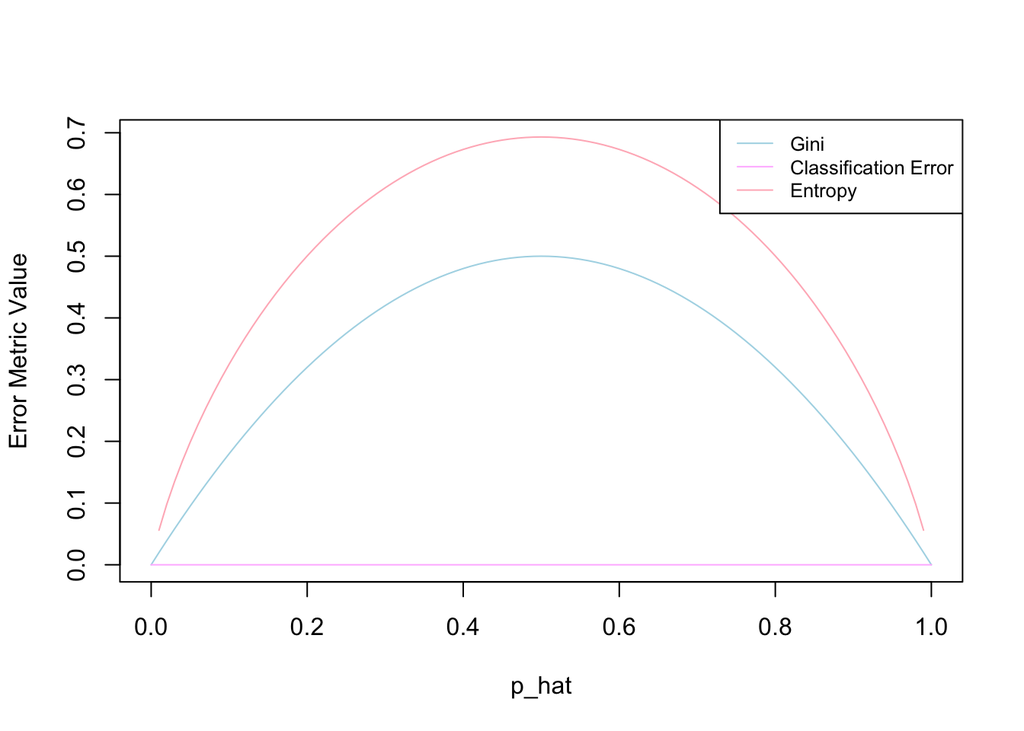

```r
p <- seq(0, 1, 0.01)
#p_(mk) represents the proportion of training observations in the mth
#region that are from the kth class

#note: gini index and entropy are defined on pg 336
gini_G <- p * (1 - p) * 2
#k = 2 classes
#gini_G <- p * (1 - p) + p2 * (1 - p2)
entropy_D <- -p * log(p) - (1 - p) * log(1 - p)
#note: classification error defined on pg 335
class_error_E <- 1 - max(p, 1 - p)

matplot(p, cbind(gini_G, class_error_E, entropy_D), type = "l", lty = 1, col = c("lightblue", "plum1", "lightpink"), xlab = "p_hat", ylab = "Error Metric Value")

legend("topright", legend = c("Gini", "Classification Error", "Entropy"), col = c("lightblue", "plum1", "lightpink"), lty = 1, cex = 0.8)
```

## 2 ISL Exercise 8.4.4 (10pts)

1. Sketch the tree corresponding to the partition of the predictor space illustrated in the left-hand panel of Figure 8.14. The numbers inside the boxes indicate the mean of Y within each region.

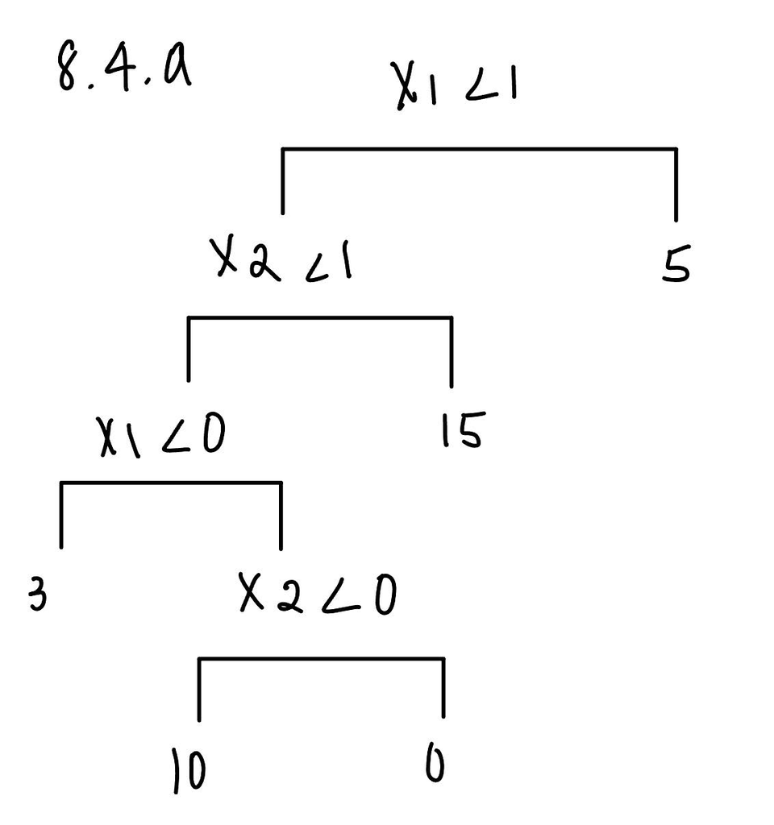

8.4.4.a Tree Sketch

2. Create a diagram similar to the left-hand panel of Figure 8.14, using the tree illustrated in the right-hand panel of the same figure. You should divide up the predictor space into the correct regions, and indicate the mean for each region.

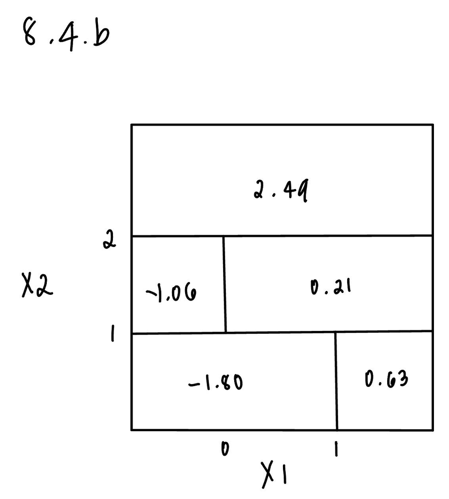

8.4.4.b Tree Sketch

## 3 ISL Exercise 8.4.5 (10pts)

Suppose we produce ten bootstrapped samples from a data set containing red and green classes. We then apply a classification tree to each bootstrapped sample and, for a specific value of X, produce 10 estimates of P(Class is Red|X): 0:1; 0:15; 0:2; 0:2; 0:55; 0:6; 0:6; 0:65; 0:7; and 0:75: There are two common ways to combine these results together into a single class prediction. One is the majority vote approach discussed in this chapter. The second approach is to classify based on the average probability. In this example, what is the final classification under each of these two approaches?

```r
P_Class_Red <- c(0.1, 0.15, 0.2, 0.2, 0.55, 0.6, 0.6, 0.65, 0.7, 0.75)
```

### 3.1 Majority Vote Approach

```r
#Majority Vote Approach
sum(P_Class_Red >= 0.5) > sum(P_Class_Red < 0.5)
```

```
[1] TRUE
```

```r
#if it returns true, then the majority of the values are greater than 0.5 which
#means the final classification is RED
```

### 3.2 Average Probability Approach

```r
#Average Probability Approach
mean(P_Class_Red)
```

```
[1] 0.45
```

```r
#if the mean is less than 0.5, then the final classification is GREEN
```

Under the majority vote approach, the the final classification is RED and under the average probability approach,the final classification is GREEN.

## 4 ISL Lab 8.3. `Boston` data set (30pts)

Follow the machine learning workflow to train regression tree, random forest, and boosting methods for predicting `medv`. Evaluate out-of-sample performance on a test set.

```r
#load data
boston_ds <- Boston
boston_ds |> tbl_summary()
```

| **Characteristic** | **N = 506**<sup>1</sup> |
| --- | --- |
| crim | 0.3 (0.1, 3.7) |
| zn | 0 (0, 13) |
| indus | 9.7 (5.2, 18.1) |
| chas | 35 (6.9%) |
| nox | 0.54 (0.45, 0.62) |
| rm | 6.21 (5.89, 6.62) |
| age | 78 (45, 94) |
| dis | 3.21 (2.10, 5.19) |
| rad |  |
| 1 | 20 (4.0%) |
| 2 | 24 (4.7%) |
| 3 | 38 (7.5%) |
| 4 | 110 (22%) |
| 5 | 115 (23%) |
| 6 | 26 (5.1%) |
| 7 | 17 (3.4%) |
| 8 | 24 (4.7%) |
| 24 | 132 (26%) |
| tax | 330 (279, 666) |
| ptratio | 19.05 (17.40, 20.20) |
| lstat | 11 (7, 17) |
| medv | 21 (17, 25) |

<sup>1</sup> Median (IQR); n (%)

```r
#check for null
is.na(boston_ds) |> colSums()
```

```
   crim      zn   indus    chas     nox      rm     age     dis     rad     tax
      0       0       0       0       0       0       0       0       0       0
ptratio   lstat    medv
      0       0       0
```

```r
# Split data, stratify on medv
set.seed(212)
boston_split <- initial_split(boston_ds, prop = 0.75, strata = medv)
boston_train <- training(boston_split)
boston_test <- testing(boston_split)
```

### 4.1 Regression Tree

```r
# Create a recipe
boston_tree <- recipe(
  medv ~ .,
  data = boston_train
) |>
  step_dummy(all_nominal()) |>
  step_naomit(medv) |>
  step_zv(all_numeric_predictors()) |>
  step_normalize(all_numeric_predictors())
# prep(training = boston_train, retain = TRUE)
#error: Can't add a trained recipe to a workflow
#removed the prep line
```

```r
# Create a model specification
regtree_mod <- decision_tree(
  cost_complexity = tune(),
  tree_depth = tune(),
  min_n = 5,
  mode = "regression",
  engine = "rpart"
)

# Bundle the recipe and model into a workflow
tree_wf <- workflow() %>%
  add_recipe(boston_tree) %>%
  add_model(regtree_mod)

# Tune
tree_grid <- grid_regular(
  cost_complexity(),
  tree_depth(),
  levels = c(100, 5)
)

# Cross-validation
set.seed(212)
tree_vfold <- vfold_cv(boston_train, v = 5, strata = medv)

# Fit the model
tree_fit <- tree_wf %>%
  tune_grid(
    resamples = tree_vfold,
    grid = tree_grid,
    metrics = metric_set(rmse, rsq)
  )
# Print the results
tree_fit
```

```
# Tuning results
# 5-fold cross-validation using stratification
# A tibble: 5 × 4
  splits           id    .metrics             .notes
  <list>           <chr> <list>               <list>
1 <split [301/77]> Fold1 <tibble [1,000 × 6]> <tibble [0 × 3]>
2 <split [302/76]> Fold2 <tibble [1,000 × 6]> <tibble [0 × 3]>
3 <split [302/76]> Fold3 <tibble [1,000 × 6]> <tibble [0 × 3]>
4 <split [303/75]> Fold4 <tibble [1,000 × 6]> <tibble [0 × 3]>
5 <split [304/74]> Fold5 <tibble [1,000 × 6]> <tibble [0 × 3]>
```

```
# A tibble: 1,000 × 8
   cost_complexity tree_depth .metric .estimator  mean     n std_err
             <dbl>      <int> <chr>   <chr>      <dbl> <int>   <dbl>
 1        1   e-10          1 rmse    standard   7.06      5  0.283
 2        1   e-10          1 rsq     standard   0.358     5  0.0475
 3        1.23e-10          1 rmse    standard   7.06      5  0.283
 4        1.23e-10          1 rsq     standard   0.358     5  0.0475
 5        1.52e-10          1 rmse    standard   7.06      5  0.283
 6        1.52e-10          1 rsq     standard   0.358     5  0.0475
 7        1.87e-10          1 rmse    standard   7.06      5  0.283
 8        1.87e-10          1 rsq     standard   0.358     5  0.0475
 9        2.31e-10          1 rmse    standard   7.06      5  0.283
10        2.31e-10          1 rsq     standard   0.358     5  0.0475
   .config
   <chr>
 1 Preprocessor1_Model001
 2 Preprocessor1_Model001
 3 Preprocessor1_Model002
 4 Preprocessor1_Model002
 5 Preprocessor1_Model003
 6 Preprocessor1_Model003
 7 Preprocessor1_Model004
 8 Preprocessor1_Model004
 9 Preprocessor1_Model005
10 Preprocessor1_Model005
# ℹ 990 more rows
```

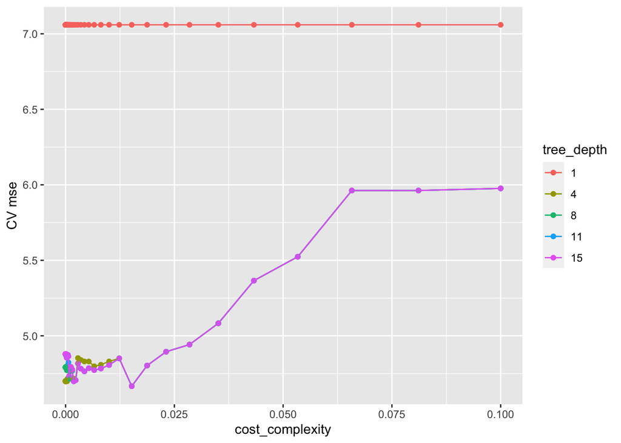

```r
tree_fit %>%
  collect_metrics() %>%
  print(width = Inf) %>%
  filter(.metric == "rmse") %>%
  mutate(tree_depth = as.factor(tree_depth)) %>%
  ggplot(mapping = aes(x = cost_complexity, y = mean, color = tree_depth)) +
  geom_point() +
  geom_line() +
  labs(x = "cost_complexity", y = "CV mse")
```

```r
tree_fit %>%
  show_best("rmse")
```

```
# A tibble: 5 × 8
  cost_complexity tree_depth .metric .estimator  mean     n std_err .config
            <dbl>      <int> <chr>   <chr>      <dbl> <int>   <dbl> <chr>
1         0.0152           4 rmse    standard    4.67     5   0.437 Preprocesso…
2         0.0152           8 rmse    standard    4.67     5   0.437 Preprocesso…
3         0.0152          11 rmse    standard    4.67     5   0.437 Preprocesso…
4         0.0152          15 rmse    standard    4.67     5   0.437 Preprocesso…
5         0.00187          8 rmse    standard    4.70     5   0.292 Preprocesso…
```

```r
best_tree <- tree_fit %>%
  select_best("rmse")
best_tree
```

```
# A tibble: 1 × 3
  cost_complexity tree_depth .config
            <dbl>      <int> <chr>
1          0.0152          4 Preprocessor1_Model191
```

```r
# Final workflow
final_wf <- tree_wf %>%
  finalize_workflow(best_tree)
final_wf
```

```
══ Workflow ════════════════════════════════════════════════════════════════════
Preprocessor: Recipe
Model: decision_tree()

── Preprocessor ────────────────────────────────────────────────────────────────
4 Recipe Steps

• step_dummy()
• step_naomit()
• step_zv()
• step_normalize()

── Model ───────────────────────────────────────────────────────────────────────
Decision Tree Model Specification (regression)

Main Arguments:
  cost_complexity = 0.0151991108295293
  tree_depth = 4
  min_n = 5

Computational engine: rpart
```

```r
# Fit the whole training set, then predict the test cases
final_fit <-
  final_wf %>%
  last_fit(boston_split)
final_fit
```

```
# Resampling results
# Manual resampling
# A tibble: 1 × 6
  splits            id               .metrics .notes   .predictions .workflow
  <list>            <chr>            <list>   <list>   <list>       <list>
1 <split [378/128]> train/test split <tibble> <tibble> <tibble>     <workflow>
```

```r
# Test metrics
final_fit %>%
  collect_metrics()
```

```
# A tibble: 2 × 4
  .metric .estimator .estimate .config
  <chr>   <chr>          <dbl> <chr>
1 rmse    standard       5.26  Preprocessor1_Model1
2 rsq     standard       0.743 Preprocessor1_Model1
```

```r
final_tree <- extract_workflow(final_fit)
final_tree
```

```
══ Workflow [trained] ══════════════════════════════════════════════════════════
Preprocessor: Recipe
Model: decision_tree()

── Preprocessor ────────────────────────────────────────────────────────────────
4 Recipe Steps

• step_dummy()
• step_naomit()
• step_zv()
• step_normalize()

── Model ───────────────────────────────────────────────────────────────────────
n= 378

node), split, n, deviance, yval
      * denotes terminal node

 1) root 378 29028.1000 22.32328
   2) lstat>=-0.5353406 244  6497.2700 18.00123
     4) lstat>=0.4581602 106  1938.3940 14.13962
       8) crim>=0.3245257 50   549.3898 11.40200 *
       9) crim< 0.3245257 56   679.6955 16.58393 *
     5) lstat< 0.4581602 138  1764.0630 20.96739 *
   3) lstat< -0.5353406 134  9673.3240 30.19328
     6) rm< 1.709276 115  4537.4670 27.88957
      12) rm< 0.5682352 66  1967.1780 24.63939
        24) dis>=-1.083798 64   640.6594 23.84687 *
        25) dis< -1.083798 2     0.0000 50.00000 *
      13) rm>=0.5682352 49   934.0078 32.26735 *
     7) rm>=1.709276 19   831.5042 44.13684 *
```

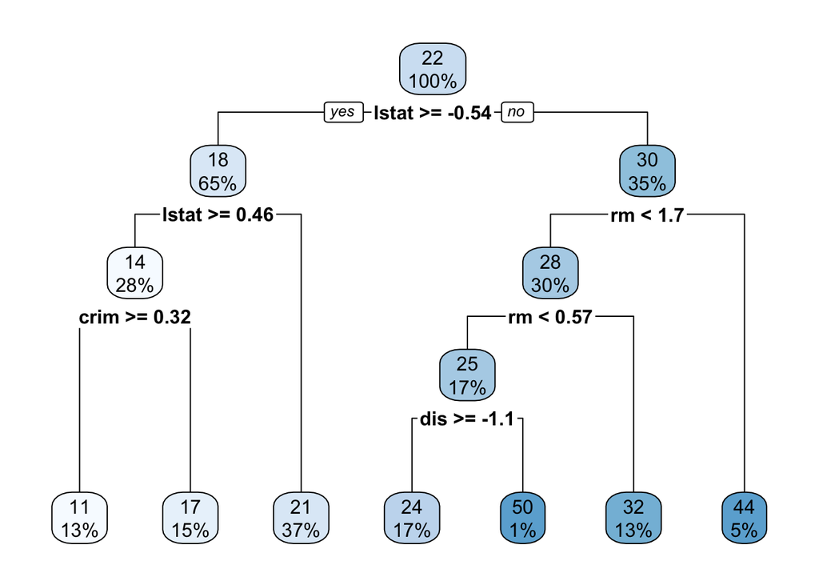

```r
final_tree %>%
  extract_fit_engine() %>%
  rpart.plot(roundint = FALSE)
```

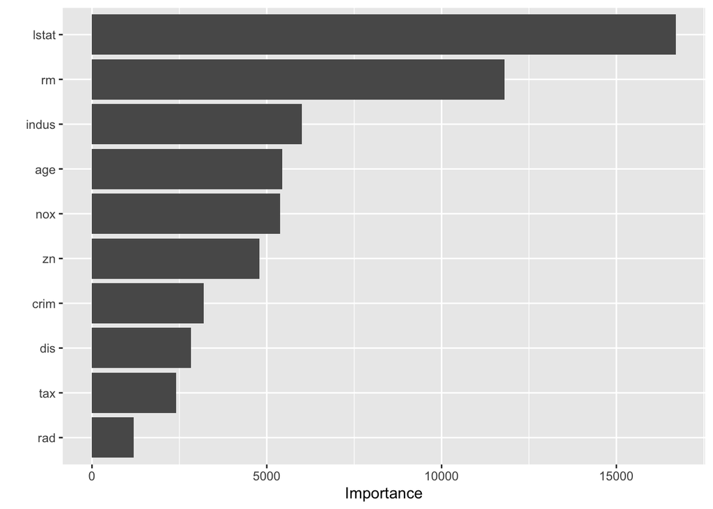

```r
final_tree %>%
  extract_fit_parsnip() %>%
  vip()
```

### 4.2 Random Forest

```r
#Random Forest recipe
boston_rf <- recipe(
  medv ~ .,
  data = boston_train
) |>
  #step_dummy(all_nominal()) |>
  # dummy not needed for random forest
  step_naomit(medv) |>
  #zero variance
  step_zv(all_numeric_predictors())
  #step_normalize(all_numeric_predictors())
  #center and scale not needed for rf

# Create a model specification
rf_mod <- rand_forest(
  mode = "regression",
  mtry = tune(),
  #trees = tune(),
  trees = tune()) |>
  #importance = TRUE) |>
  set_engine("ranger")

rf_mod
```

```
Random Forest Model Specification (regression)

Main Arguments:
  mtry = tune()
  trees = tune()

Computational engine: ranger
```

```r
# Bundle the recipe and model into a workflow
rf_wf <- workflow() %>%
  add_recipe(boston_rf) %>%
  add_model(rf_mod)

# Tune
rf_grid <- grid_regular(
  trees(range = c(100L, 300L)),
  mtry(range = c(1L, 5L)),
  levels = c(3, 5)
  )
rf_grid
```

```
# A tibble: 15 × 2
   trees  mtry
   <int> <int>
 1   100     1
 2   200     1
 3   300     1
 4   100     2
 5   200     2
 6   300     2
 7   100     3
 8   200     3
 9   300     3
10   100     4
11   200     4
12   300     4
13   100     5
14   200     5
15   300     5
```

```r
# Cross-validation
set.seed(212)
rf_vfold <- vfold_cv(boston_train, v = 5, strata = medv)

# Fit the model
rf_fit <- rf_wf %>%
  tune_grid(
    resamples = rf_vfold,
    grid = rf_grid,
    metrics = metric_set(rmse, rsq)
  )
# Print the results
rf_fit
```

```
# Tuning results
# 5-fold cross-validation using stratification
# A tibble: 5 × 4
  splits           id    .metrics          .notes
  <list>           <chr> <list>            <list>
1 <split [301/77]> Fold1 <tibble [30 × 6]> <tibble [0 × 3]>
2 <split [302/76]> Fold2 <tibble [30 × 6]> <tibble [0 × 3]>
3 <split [302/76]> Fold3 <tibble [30 × 6]> <tibble [0 × 3]>
4 <split [303/75]> Fold4 <tibble [30 × 6]> <tibble [0 × 3]>
5 <split [304/74]> Fold5 <tibble [30 × 6]> <tibble [0 × 3]>
```

```
# A tibble: 30 × 8
    mtry trees .metric .estimator  mean     n std_err .config
   <int> <int> <chr>   <chr>      <dbl> <int>   <dbl> <chr>
 1     1   100 rmse    standard   4.63      5  0.502  Preprocessor1_Model01
 2     1   100 rsq     standard   0.753     5  0.0276 Preprocessor1_Model01
 3     1   200 rmse    standard   4.63      5  0.526  Preprocessor1_Model02
 4     1   200 rsq     standard   0.750     5  0.0328 Preprocessor1_Model02
 5     1   300 rmse    standard   4.53      5  0.456  Preprocessor1_Model03
 6     1   300 rsq     standard   0.764     5  0.0237 Preprocessor1_Model03
 7     2   100 rmse    standard   3.89      5  0.406  Preprocessor1_Model04
 8     2   100 rsq     standard   0.819     5  0.0175 Preprocessor1_Model04
 9     2   200 rmse    standard   3.88      5  0.362  Preprocessor1_Model05
10     2   200 rsq     standard   0.821     5  0.0116 Preprocessor1_Model05
# ℹ 20 more rows
```

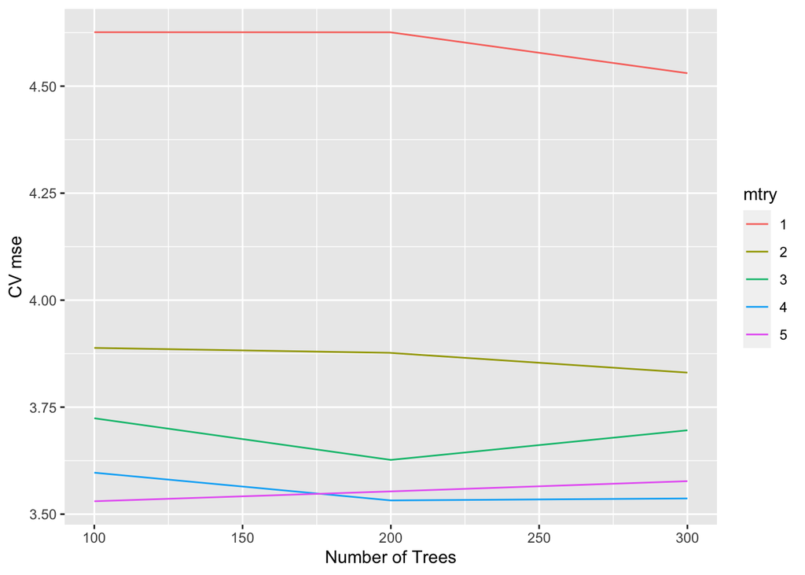

```r
rf_fit %>%
  collect_metrics() %>%
  print(width = Inf) %>%
  filter(.metric == "rmse") %>%
  mutate(mtry = as.factor(mtry)) %>%
  ggplot(mapping = aes(x = trees, y = mean, color = mtry)) +
  #geom_point() +
  geom_line() +
  labs(x = "Number of Trees", y = "CV mse")
```

```r
rf_fit %>%
  show_best("rmse")
```

```
# A tibble: 5 × 8
   mtry trees .metric .estimator  mean     n std_err .config
  <int> <int> <chr>   <chr>      <dbl> <int>   <dbl> <chr>
1     5   100 rmse    standard    3.53     5   0.229 Preprocessor1_Model13
2     4   200 rmse    standard    3.53     5   0.268 Preprocessor1_Model11
3     4   300 rmse    standard    3.54     5   0.280 Preprocessor1_Model12
4     5   200 rmse    standard    3.55     5   0.249 Preprocessor1_Model14
5     5   300 rmse    standard    3.58     5   0.261 Preprocessor1_Model15
```

```r
best_rf <- rf_fit %>%
  select_best("rmse")
best_rf
```

```
# A tibble: 1 × 3
   mtry trees .config
  <int> <int> <chr>
1     5   100 Preprocessor1_Model13
```

```r
# Final workflow
final_wf_rf <- rf_wf %>%
  finalize_workflow(best_rf)
final_wf_rf
```

```
══ Workflow ════════════════════════════════════════════════════════════════════
Preprocessor: Recipe
Model: rand_forest()

── Preprocessor ────────────────────────────────────────────────────────────────
2 Recipe Steps

• step_naomit()
• step_zv()

── Model ───────────────────────────────────────────────────────────────────────
Random Forest Model Specification (regression)

Main Arguments:
  mtry = 5
  trees = 100

Computational engine: ranger
```

```r
# Fit the whole training set, then predict the test cases
final_fit_rf <-
  final_wf_rf %>%
  last_fit(boston_split)
final_fit_rf
```

```
# Resampling results
# Manual resampling
# A tibble: 1 × 6
  splits            id               .metrics .notes   .predictions .workflow
  <list>            <chr>            <list>   <list>   <list>       <list>
1 <split [378/128]> train/test split <tibble> <tibble> <tibble>     <workflow>
```

```r
# Test metrics
final_fit_rf %>%
  collect_metrics()
```

```
# A tibble: 2 × 4
  .metric .estimator .estimate .config
  <chr>   <chr>          <dbl> <chr>
1 rmse    standard       3.82  Preprocessor1_Model1
2 rsq     standard       0.876 Preprocessor1_Model1
```

```r
final_rf <- extract_workflow(final_fit_rf)
final_rf
```

```
══ Workflow [trained] ══════════════════════════════════════════════════════════
Preprocessor: Recipe
Model: rand_forest()

── Preprocessor ────────────────────────────────────────────────────────────────
2 Recipe Steps

• step_naomit()
• step_zv()

── Model ───────────────────────────────────────────────────────────────────────
Ranger result

Call:
 ranger::ranger(x = maybe_data_frame(x), y = y, mtry = min_cols(~5L,      x), num.trees = ~100L, num.threads = 1, verbose = FALSE,      seed = sample.int(10^5, 1))

Type:                             Regression
Number of trees:                  100
Sample size:                      378
Number of independent variables:  12
Mtry:                             5
Target node size:                 5
Variable importance mode:         none
Splitrule:                        variance
OOB prediction error (MSE):       12.69049
R squared (OOB):                  0.8351833
```

```r
final_rf %>%
  extract_fit_parsnip()
```

```
parsnip model object

Ranger result

Call:
 ranger::ranger(x = maybe_data_frame(x), y = y, mtry = min_cols(~5L,      x), num.trees = ~100L, num.threads = 1, verbose = FALSE,      seed = sample.int(10^5, 1))

Type:                             Regression
Number of trees:                  100
Sample size:                      378
Number of independent variables:  12
Mtry:                             5
Target node size:                 5
Variable importance mode:         none
Splitrule:                        variance
OOB prediction error (MSE):       12.69049
R squared (OOB):                  0.8351833
```

### 4.3 Boosting Methods

```r
#Boosting Methods

# Create a recipe
boston_boost <- recipe(
  medv ~ .,
  data = boston_train
) |>
  #step_dummy(all_nominal()) |>
  step_naomit(medv) |>
  step_zv(all_numeric_predictors())
  #step_normalize(all_numeric_predictors())
boston_boost

# Create a model specification
boost_mod <- boost_tree(
    mode = "regression",
    trees = 1000,
    tree_depth = tune(),
    learn_rate = tune()
  ) %>%
  set_engine("xgboost")
boost_mod
```

```
Boosted Tree Model Specification (regression)

Main Arguments:
  trees = 1000
  tree_depth = tune()
  learn_rate = tune()

Computational engine: xgboost
```

```r
# Bundle the recipe and model into a workflow
boost_wf <- workflow() %>%
  add_recipe(boston_boost) %>%
  add_model(boost_mod)
boost_wf
```

```
══ Workflow ════════════════════════════════════════════════════════════════════
Preprocessor: Recipe
Model: boost_tree()

── Preprocessor ────────────────────────────────────────────────────────────────
2 Recipe Steps

• step_naomit()
• step_zv()

── Model ───────────────────────────────────────────────────────────────────────
Boosted Tree Model Specification (regression)

Main Arguments:
  trees = 1000
  tree_depth = tune()
  learn_rate = tune()

Computational engine: xgboost
```

```r
#Tune
param_grid <- grid_regular(
  tree_depth(range = c(1L, 4L)),
  learn_rate(range = c(-3, -0.5), trans = log10_trans()),
  levels = c(4, 10)
  )
param_grid
```

```
# A tibble: 40 × 2
   tree_depth learn_rate
        <int>      <dbl>
 1          1    0.001
 2          2    0.001
 3          3    0.001
 4          4    0.001
 5          1    0.00190
 6          2    0.00190
 7          3    0.00190
 8          4    0.00190
 9          1    0.00359
10          2    0.00359
# ℹ 30 more rows
```

```r
#Cross-validation
set.seed(212)
boost_vfold <- vfold_cv(boston_train, v = 5, strata = medv)

# Fit the model
boost_fit <- boost_wf %>%
  tune_grid(
    resamples = boost_vfold,
    grid = param_grid,
    metrics = metric_set(rmse, rsq)
  )
# Print the results
boost_fit
```

```
# Tuning results
# 5-fold cross-validation using stratification
# A tibble: 5 × 4
  splits           id    .metrics          .notes
  <list>           <chr> <list>            <list>
1 <split [301/77]> Fold1 <tibble [80 × 6]> <tibble [0 × 3]>
2 <split [302/76]> Fold2 <tibble [80 × 6]> <tibble [0 × 3]>
3 <split [302/76]> Fold3 <tibble [80 × 6]> <tibble [0 × 3]>
4 <split [303/75]> Fold4 <tibble [80 × 6]> <tibble [0 × 3]>
5 <split [304/74]> Fold5 <tibble [80 × 6]> <tibble [0 × 3]>
```

```
# A tibble: 80 × 8
   tree_depth learn_rate .metric .estimator   mean     n std_err
        <int>      <dbl> <chr>   <chr>       <dbl> <int>   <dbl>
 1          1    0.001   rmse    standard   10.3       5 0.429
 2          1    0.001   rsq     standard    0.668     5 0.0235
 3          2    0.001   rmse    standard    9.81      5 0.364
 4          2    0.001   rsq     standard    0.761     5 0.00792
 5          3    0.001   rmse    standard    9.63      5 0.315
 6          3    0.001   rsq     standard    0.815     5 0.00856
 7          4    0.001   rmse    standard    9.62      5 0.289
 8          4    0.001   rsq     standard    0.816     5 0.0128
 9          1    0.00190 rmse    standard    6.35      5 0.387
10          1    0.00190 rsq     standard    0.727     5 0.0137
   .config
   <chr>
 1 Preprocessor1_Model01
 2 Preprocessor1_Model01
 3 Preprocessor1_Model02
 4 Preprocessor1_Model02
 5 Preprocessor1_Model03
 6 Preprocessor1_Model03
 7 Preprocessor1_Model04
 8 Preprocessor1_Model04
 9 Preprocessor1_Model05
10 Preprocessor1_Model05
# ℹ 70 more rows
```

[figure not shown]

```r
boost_fit %>%
  collect_metrics() %>%
  print(width = Inf) %>%
  filter(.metric == "rmse") %>%
  ggplot(mapping = aes(x = learn_rate, y = mean, color = factor(tree_depth))) +
  geom_point() +
  geom_line() +
  labs(x = "Learning Rate", y = "CV AUC") +
  scale_x_log10()
```

```r
boost_fit %>%
  show_best("rmse")
```

```
# A tibble: 5 × 8
  tree_depth learn_rate .metric .estimator  mean     n std_err .config
       <int>      <dbl> <chr>   <chr>      <dbl> <int>   <dbl> <chr>
1          3     0.0464 rmse    standard    3.16     5   0.222 Preprocessor1_Mo…
2          3     0.0245 rmse    standard    3.17     5   0.222 Preprocessor1_Mo…
3          4     0.0245 rmse    standard    3.18     5   0.229 Preprocessor1_Mo…
4          4     0.0129 rmse    standard    3.18     5   0.226 Preprocessor1_Mo…
5          4     0.0464 rmse    standard    3.19     5   0.225 Preprocessor1_Mo…
```

```r
best_boost <- boost_fit %>%
  select_best("rmse")
best_boost
```

```
# A tibble: 1 × 3
  tree_depth learn_rate .config
       <int>      <dbl> <chr>
1          3     0.0464 Preprocessor1_Model27
```

```r
# Final workflow
final_wf_boost <- boost_wf %>%
  finalize_workflow(best_boost)
final_wf_boost
```

```
══ Workflow ════════════════════════════════════════════════════════════════════
Preprocessor: Recipe
Model: boost_tree()

── Preprocessor ────────────────────────────────────────────────────────────────
2 Recipe Steps

• step_naomit()
• step_zv()

── Model ───────────────────────────────────────────────────────────────────────
Boosted Tree Model Specification (regression)

Main Arguments:
  trees = 1000
  tree_depth = 3
  learn_rate = 0.0464158883361278

Computational engine: xgboost
```

```r
# Fit the whole training set, then predict the test cases
final_fit_boost <-
  final_wf_boost %>%
  last_fit(boston_split)
final_fit_boost
```

```
# Resampling results
# Manual resampling
# A tibble: 1 × 6
  splits            id               .metrics .notes   .predictions .workflow
  <list>            <chr>            <list>   <list>   <list>       <list>
1 <split [378/128]> train/test split <tibble> <tibble> <tibble>     <workflow>
```

```r
# Test metrics
final_fit_boost %>%
  collect_metrics()
```

```
# A tibble: 2 × 4
  .metric .estimator .estimate .config
  <chr>   <chr>          <dbl> <chr>
1 rmse    standard       3.37  Preprocessor1_Model1
2 rsq     standard       0.895 Preprocessor1_Model1
```

```r
#library(rpart.plot)
final_boost<- extract_workflow(final_fit_boost)
final_boost
```

```
══ Workflow [trained] ══════════════════════════════════════════════════════════
Preprocessor: Recipe
Model: boost_tree()

── Preprocessor ────────────────────────────────────────────────────────────────
2 Recipe Steps

• step_naomit()
• step_zv()

── Model ───────────────────────────────────────────────────────────────────────
##### xgb.Booster
raw: 1.1 Mb
call:
  xgboost::xgb.train(params = list(eta = 0.0464158883361278, max_depth = 3L,
    gamma = 0, colsample_bytree = 1, colsample_bynode = 1, min_child_weight = 1,
    subsample = 1), data = x$data, nrounds = 1000, watchlist = x$watchlist,
    verbose = 0, nthread = 1, objective = "reg:squarederror")
params (as set within xgb.train):
  eta = "0.0464158883361278", max_depth = "3", gamma = "0", colsample_bytree = "1", colsample_bynode = "1", min_child_weight = "1", subsample = "1", nthread = "1", objective = "reg:squarederror", validate_parameters = "TRUE"
xgb.attributes:
  niter
callbacks:
  cb.evaluation.log()
# of features: 12
niter: 1000
nfeatures : 12
evaluation_log:
     iter training_rmse
    <num>         <num>
        1    22.4833651
        2    21.4976379
---
      999     0.4452729
     1000     0.4449567
```

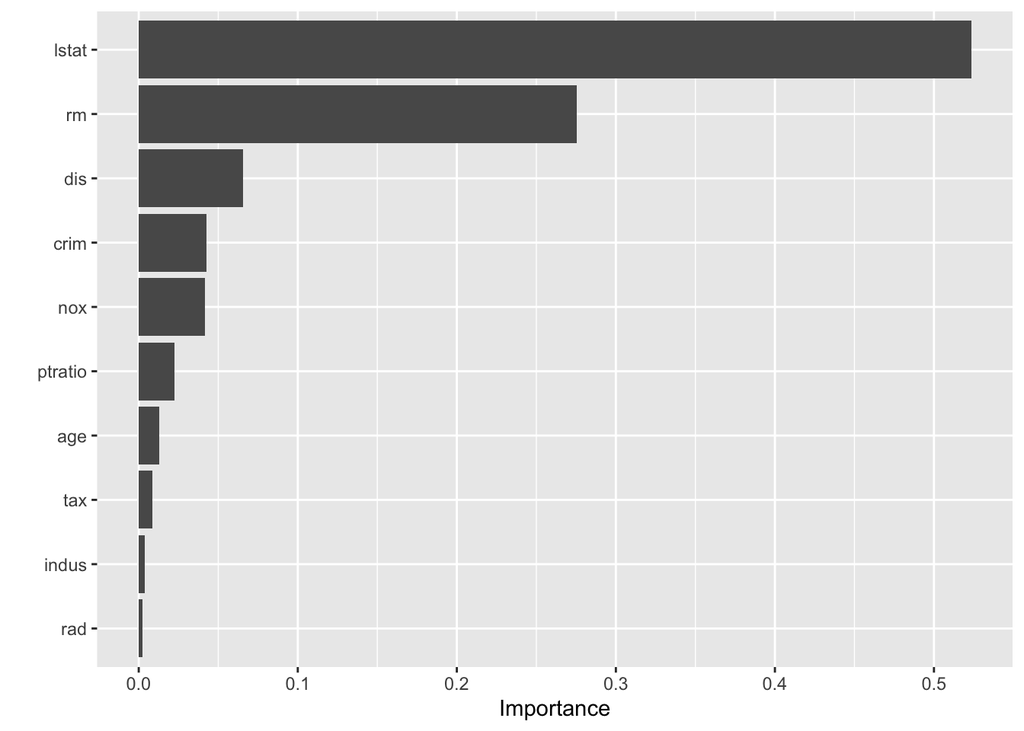

```r
library(vip)

final_boost %>%
  extract_fit_parsnip() %>%
  vip()
```

### 4.4 Evaluate out-of-sample performance on a test set

Note: same values computed above, but easier to compare side by side

```r
#Tree Regression
tree_predictions <-predict(final_tree, new_data = boston_test) %>%
  bind_cols(boston_test)

# Calculate RMSE and R-squared
tree_rmse <- sqrt(mean((tree_predictions$medv - tree_predictions$.pred)^2))
tree_rsq <- cor(tree_predictions$medv, tree_predictions$.pred)^2
tree_rmse
```

```
[1] 5.262057
```

```r
tree_rsq
```

```
[1] 0.7428685
```

```r
#Random Forests
rf_predictions <- predict(final_rf, new_data = boston_test) %>%
  bind_cols(boston_test)

# Calculate RMSE and R-squared
rf_rmse <- sqrt(mean((rf_predictions$medv - rf_predictions$.pred)^2))
rf_rsq <- cor(rf_predictions$medv, rf_predictions$.pred)^2
rf_rmse
```

```
[1] 3.817871
```

```r
rf_rsq
```

```
[1] 0.8763712
```

```r
#Boosting
boost_predictions <- predict(final_boost, new_data = boston_test) %>%
  bind_cols(boston_test)

# Calculate RMSE and R-squared
boost_rmse <- sqrt(mean((boost_predictions$medv - boost_predictions$.pred)^2))
boost_rsq <- cor(boost_predictions$medv, boost_predictions$.pred)^2
boost_rmse
```

```
[1] 3.374857
```

```r
boost_rsq
```

```
[1] 0.8948202
```

In summary, the boosting model has the lowest RMSE and the highest R-squared value, indicating that it has the best out-of-sample performance on the test set. The random forest model has the second lowest RMSE and R-squared value, and the regression tree model has the highest RMSE and the lowest R-squared value. This suggests that the boosting model is the best model for predicting median house values in the Boston data set.

## 5 ISL Lab 8.3 `Carseats` data set (30pts)

Follow the machine learning workflow to train classification tree, random forest, and boosting methods for classifying `Sales <= 8` versus `Sales > 8`. Evaluate out-of-sample performance on a test set.

Follow the machine learning workflow to train classification tree, random forest, and boosting methods for classifying Sales <= 8 versus Sales > 8. Evaluate out-of-sample performance on a test set.

```r
#load data
carseats_ds <- Carseats
carseats_ds |> tbl_summary()
```

| **Characteristic** | **N = 400**<sup>1</sup> |
| --- | --- |
| Sales | 7.49 (5.39, 9.32) |
| CompPrice | 125 (115, 135) |
| Income | 69 (43, 91) |
| Advertising | 5.0 (0.0, 12.0) |
| Population | 272 (139, 399) |
| Price | 117 (100, 131) |
| ShelveLoc |  |
| Bad | 96 (24%) |
| Good | 85 (21%) |
| Medium | 219 (55%) |
| Age | 55 (40, 66) |
| Education |  |
| 10 | 48 (12%) |
| 11 | 48 (12%) |
| 12 | 49 (12%) |
| 13 | 43 (11%) |
| 14 | 40 (10%) |
| 15 | 36 (9.0%) |
| 16 | 47 (12%) |
| 17 | 49 (12%) |
| 18 | 40 (10%) |
| Urban | 282 (71%) |
| US | 258 (65%) |

<sup>1</sup> Median (IQR); n (%)

```r
#check for null
is.na(boston_ds) |> colSums()
```

```
   crim      zn   indus    chas     nox      rm     age     dis     rad     tax
      0       0       0       0       0       0       0       0       0       0
ptratio   lstat    medv
      0       0       0
```

```r
# Recode Sales as a Factor
carseats_ds$Sales <- factor(ifelse(carseats_ds$Sales > 8, "High", "Low"))
head(carseats_ds,5)
```

```
  Sales CompPrice Income Advertising Population Price ShelveLoc Age Education
1  High       138     73          11        276   120       Bad  42        17
2  High       111     48          16        260    83      Good  65        10
3  High       113     35          10        269    80    Medium  59        12
4   Low       117    100           4        466    97    Medium  55        14
5   Low       141     64           3        340   128       Bad  38        13
  Urban  US
1   Yes Yes
2   Yes Yes
3   Yes Yes
4   Yes Yes
5   Yes  No
```

```r
#Split Data
set.seed(212)

carseats_split <- initial_split(
  carseats_ds,
  prop = 0.75,
  strata = Sales)
carseats_split
```

```
<Training/Testing/Total>
<300/100/400>
```

```r
carseats_train <- training(carseats_split)
carseats_test <- testing(carseats_split)

dim(carseats_train)
```

```
[1] 300  11
```

```r
dim(carseats_test)
```

```
[1] 100  11
```

```r
# Create a recipe
carseats_tree <- recipe(
  Sales ~ .,
  data = carseats_train
) |>
  step_naomit(all_predictors()) |>
  step_dummy(all_nominal_predictors()) |>
  step_zv(all_numeric_predictors()) |>
  step_normalize(all_numeric_predictors())
# prep(training = boston_train, retain = TRUE)
#error: Can't add a trained recipe to a workflow
#removed the prep line

carseats_tree

# Create a model specification
classtree_mod <- decision_tree(
  cost_complexity = tune(),
  tree_depth = tune(),
  min_n = 5,
  mode = "classification",
  engine = "rpart"
  )

#Bundle the recipe and model into a workflow
classtree_wf <- workflow() %>%
  add_recipe(carseats_tree) %>%
  add_model(classtree_mod)
classtree_wf
```

```
══ Workflow ════════════════════════════════════════════════════════════════════
Preprocessor: Recipe
Model: decision_tree()

── Preprocessor ────────────────────────────────────────────────────────────────
4 Recipe Steps

• step_naomit()
• step_dummy()
• step_zv()
• step_normalize()

── Model ───────────────────────────────────────────────────────────────────────
Decision Tree Model Specification (classification)

Main Arguments:
  cost_complexity = tune()
  tree_depth = tune()
  min_n = 5

Computational engine: rpart
```

```r
#Tune
tree_grid <- grid_regular(cost_complexity(),
                          tree_depth(),
                          levels = c(100,5))

#Cross-validation
set.seed(212)

classtree_folds <- vfold_cv(carseats_train, v = 5)
classtree_folds
```

```
#  5-fold cross-validation
# A tibble: 5 × 2
  splits           id
  <list>           <chr>
1 <split [240/60]> Fold1
2 <split [240/60]> Fold2
3 <split [240/60]> Fold3
4 <split [240/60]> Fold4
5 <split [240/60]> Fold5
```

```r
#Fit C-V
classtree_fit <- classtree_wf %>%
  tune_grid(
    resamples = classtree_folds,
    grid = tree_grid,
    metrics = metric_set(accuracy, roc_auc)
    )
classtree_fit
```

```
# Tuning results
# 5-fold cross-validation
# A tibble: 5 × 4
  splits           id    .metrics             .notes
  <list>           <chr> <list>               <list>
1 <split [240/60]> Fold1 <tibble [1,000 × 6]> <tibble [0 × 3]>
2 <split [240/60]> Fold2 <tibble [1,000 × 6]> <tibble [0 × 3]>
3 <split [240/60]> Fold3 <tibble [1,000 × 6]> <tibble [0 × 3]>
4 <split [240/60]> Fold4 <tibble [1,000 × 6]> <tibble [0 × 3]>
5 <split [240/60]> Fold5 <tibble [1,000 × 6]> <tibble [0 × 3]>
```

```
# A tibble: 1,000 × 8
   cost_complexity tree_depth .metric  .estimator  mean     n std_err
             <dbl>      <int> <chr>    <chr>      <dbl> <int>   <dbl>
 1        1   e-10          1 accuracy binary     0.717     5  0.0236
 2        1   e-10          1 roc_auc  binary     0.674     5  0.0116
 3        1.23e-10          1 accuracy binary     0.717     5  0.0236
 4        1.23e-10          1 roc_auc  binary     0.674     5  0.0116
 5        1.52e-10          1 accuracy binary     0.717     5  0.0236
 6        1.52e-10          1 roc_auc  binary     0.674     5  0.0116
 7        1.87e-10          1 accuracy binary     0.717     5  0.0236
 8        1.87e-10          1 roc_auc  binary     0.674     5  0.0116
 9        2.31e-10          1 accuracy binary     0.717     5  0.0236
10        2.31e-10          1 roc_auc  binary     0.674     5  0.0116
   .config
   <chr>
 1 Preprocessor1_Model001
 2 Preprocessor1_Model001
 3 Preprocessor1_Model002
 4 Preprocessor1_Model002
 5 Preprocessor1_Model003
 6 Preprocessor1_Model003
 7 Preprocessor1_Model004
 8 Preprocessor1_Model004
 9 Preprocessor1_Model005
10 Preprocessor1_Model005
# ℹ 990 more rows
```

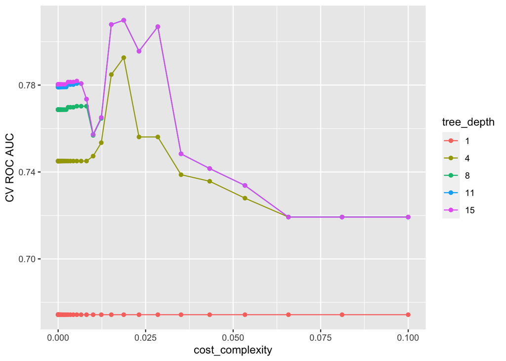

```r
classtree_fit %>%
  collect_metrics() %>%
  print(width = Inf) %>%
  filter(.metric == "roc_auc") %>%
  mutate(tree_depth = as.factor(tree_depth)) %>%
  ggplot(mapping = aes(x = cost_complexity, y = mean, color = tree_depth)) +
  geom_point() +
  geom_line() +
  labs(x = "cost_complexity", y = "CV ROC AUC", color = "tree_depth")
```

```r
classtree_fit %>%
  show_best("roc_auc")
```

```
# A tibble: 5 × 8
  cost_complexity tree_depth .metric .estimator  mean     n std_err .config
            <dbl>      <int> <chr>   <chr>      <dbl> <int>   <dbl> <chr>
1          0.0187          8 roc_auc binary     0.810     5  0.0294 Preprocesso…
2          0.0187         11 roc_auc binary     0.810     5  0.0294 Preprocesso…
3          0.0187         15 roc_auc binary     0.810     5  0.0294 Preprocesso…
4          0.0152          8 roc_auc binary     0.808     5  0.0342 Preprocesso…
5          0.0152         11 roc_auc binary     0.808     5  0.0342 Preprocesso…
```

```r
best_classtree <- classtree_fit %>%
  select_best("roc_auc")
best_classtree
```

```
# A tibble: 1 × 3
  cost_complexity tree_depth .config
            <dbl>      <int> <chr>
1          0.0187          8 Preprocessor1_Model292
```

```r
# Final workflow
final_wf_classtree <- classtree_wf %>%
  finalize_workflow(best_classtree)

# Fit the whole training set, then predict the test cases
final_fit_classtree <-
  final_wf_classtree %>%
  last_fit(carseats_split)
final_fit_classtree
```

```
# Resampling results
# Manual resampling
# A tibble: 1 × 6
  splits            id               .metrics .notes   .predictions .workflow
  <list>            <chr>            <list>   <list>   <list>       <list>
1 <split [300/100]> train/test split <tibble> <tibble> <tibble>     <workflow>
```

```r
# Test metrics
final_fit_classtree %>%
  collect_metrics()
```

```
# A tibble: 2 × 4
  .metric  .estimator .estimate .config
  <chr>    <chr>          <dbl> <chr>
1 accuracy binary         0.78  Preprocessor1_Model1
2 roc_auc  binary         0.807 Preprocessor1_Model1
```

```r
#Visualize the final model
final_classtree <- extract_workflow(final_fit_classtree)
final_classtree
```

```
══ Workflow [trained] ══════════════════════════════════════════════════════════
Preprocessor: Recipe
Model: decision_tree()

── Preprocessor ────────────────────────────────────────────────────────────────
4 Recipe Steps

• step_naomit()
• step_dummy()
• step_zv()
• step_normalize()

── Model ───────────────────────────────────────────────────────────────────────
n= 300

node), split, n, loss, yval, (yprob)
      * denotes terminal node

  1) root 300 123 Low (0.41000000 0.59000000)
    2) ShelveLoc_Good>=0.6985981 64  13 High (0.79687500 0.20312500)
      4) Price< 1.151572 54   6 High (0.88888889 0.11111111) *
      5) Price>=1.151572 10   3 Low (0.30000000 0.70000000) *
    3) ShelveLoc_Good< 0.6985981 236  72 Low (0.30508475 0.69491525)
      6) Price< -0.9942146 34  10 High (0.70588235 0.29411765)
       12) Income>=-0.4092414 26   4 High (0.84615385 0.15384615) *
       13) Income< -0.4092414 8   2 Low (0.25000000 0.75000000) *
      7) Price>=-0.9942146 202  48 Low (0.23762376 0.76237624)
       14) Advertising>=1.044477 33  14 High (0.57575758 0.42424242)
         28) Age< -0.3909271 18   3 High (0.83333333 0.16666667) *
         29) Age>=-0.3909271 15   4 Low (0.26666667 0.73333333)
           58) CompPrice>=-0.02760221 5   1 High (0.80000000 0.20000000) *
           59) CompPrice< -0.02760221 10   0 Low (0.00000000 1.00000000) *
       15) Advertising< 1.044477 169  29 Low (0.17159763 0.82840237)
         30) CompPrice>=-0.02760221 93  25 Low (0.26881720 0.73118280)
           60) Price< -0.264647 18   6 High (0.66666667 0.33333333)
            120) ShelveLoc_Medium>=-0.05332026 13   1 High (0.92307692 0.07692308) *
            121) ShelveLoc_Medium< -0.05332026 5   0 Low (0.00000000 1.00000000) *
           61) Price>=-0.264647 75  13 Low (0.17333333 0.82666667) *
         31) CompPrice< -0.02760221 76   4 Low (0.05263158 0.94736842) *
```

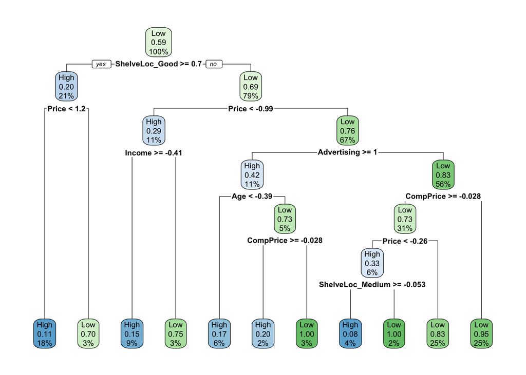

```r
final_classtree %>%
  extract_fit_engine() %>%
  rpart.plot(roundint = FALSE)
```

The final classification tree model has a ROC AUC of approximately 0.81 and an accuracy of 0.78. Higher ROC AUC and accuracy values close to 1 indicate better model performance. The ROC AUC value of 0.81 indicates that the model has an 81% chance of distinguishing between the two classes. Accuracy measures the proportion of correctly classified observations. Thus, the model was able to correctly classify 78% of the observations.

### 5.2 Random Forest

```r
# Create a recipe
carseats_rf <- recipe(
  Sales ~ .,
  data = carseats_train
) |>
  step_naomit(all_predictors()) |>
  #step_dummy(all_nominal_predictors()) |>
  step_zv(all_numeric_predictors())
  #step_normalize(all_numeric_predictors())
carseats_rf

# Create a model specification
classrf_mod <- rand_forest(
  mode = "classification",
  mtry = tune(),
  trees = tune()
  ) %>%
  set_engine("ranger")
classrf_mod
```

```
Random Forest Model Specification (classification)

Main Arguments:
  mtry = tune()
  trees = tune()

Computational engine: ranger
```

```r
#Bundle the recipe and model into a workflow
classrf_wf <- workflow() %>%
  add_recipe(carseats_rf) %>%
  add_model(classrf_mod)
classrf_wf
```

```
══ Workflow ════════════════════════════════════════════════════════════════════
Preprocessor: Recipe
Model: rand_forest()

── Preprocessor ────────────────────────────────────────────────────────────────
2 Recipe Steps

• step_naomit()
• step_zv()

── Model ───────────────────────────────────────────────────────────────────────
Random Forest Model Specification (classification)

Main Arguments:
  mtry = tune()
  trees = tune()

Computational engine: ranger
```

```r
#Tune
param_grid <- grid_regular(
  trees(range = c(100L, 300L)),
  mtry(range = c(1L, 5L)),
  levels = c(3, 5)
  )
param_grid
```

```
# A tibble: 15 × 2
   trees  mtry
   <int> <int>
 1   100     1
 2   200     1
 3   300     1
 4   100     2
 5   200     2
 6   300     2
 7   100     3
 8   200     3
 9   300     3
10   100     4
11   200     4
12   300     4
13   100     5
14   200     5
15   300     5
```

```r
#Cross-validation
set.seed(212)

classrf_folds <- vfold_cv(carseats_train, v = 5)
classrf_folds
```

```
#  5-fold cross-validation
# A tibble: 5 × 2
  splits           id
  <list>           <chr>
1 <split [240/60]> Fold1
2 <split [240/60]> Fold2
3 <split [240/60]> Fold3
4 <split [240/60]> Fold4
5 <split [240/60]> Fold5
```

```r
#Fit C-V
classrf_fit <- classrf_wf %>%
  tune_grid(
    resamples = classrf_folds,
    grid = param_grid,
    metrics = metric_set(accuracy, roc_auc)
    )
```

```
# A tibble: 30 × 8
    mtry trees .metric  .estimator  mean     n std_err .config
   <int> <int> <chr>    <chr>      <dbl> <int>   <dbl> <chr>
 1     1   100 accuracy binary     0.767     5 0.0321  Preprocessor1_Model01
 2     1   100 roc_auc  binary     0.871     5 0.00999 Preprocessor1_Model01
 3     1   200 accuracy binary     0.773     5 0.0201  Preprocessor1_Model02
 4     1   200 roc_auc  binary     0.869     5 0.00811 Preprocessor1_Model02
 5     1   300 accuracy binary     0.78      5 0.0249  Preprocessor1_Model03
 6     1   300 roc_auc  binary     0.879     5 0.00856 Preprocessor1_Model03
 7     2   100 accuracy binary     0.807     5 0.0310  Preprocessor1_Model04
 8     2   100 roc_auc  binary     0.890     5 0.0131  Preprocessor1_Model04
 9     2   200 accuracy binary     0.81      5 0.0251  Preprocessor1_Model05
10     2   200 roc_auc  binary     0.895     5 0.0139  Preprocessor1_Model05
# ℹ 20 more rows
```

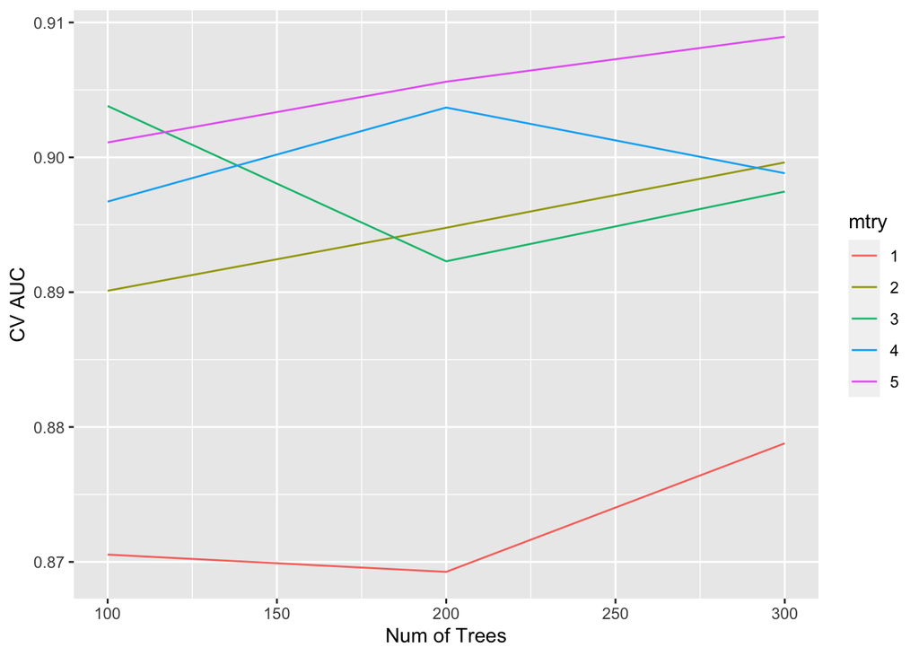

```r
classrf_fit %>%
  collect_metrics() %>%
  print(width = Inf) %>%
  filter(.metric == "roc_auc") %>%
  mutate(mtry = as.factor(mtry)) %>%
  ggplot(mapping = aes(x = trees, y = mean, color = mtry)) +
  # geom_point() +
  geom_line() +
  labs(x = "Num of Trees", y = "CV AUC")
```

```r
classrf_fit %>%
  show_best("roc_auc")
```

```
# A tibble: 5 × 8
   mtry trees .metric .estimator  mean     n std_err .config
  <int> <int> <chr>   <chr>      <dbl> <int>   <dbl> <chr>
1     5   300 roc_auc binary     0.909     5  0.0170 Preprocessor1_Model15
2     5   200 roc_auc binary     0.906     5  0.0170 Preprocessor1_Model14
3     3   100 roc_auc binary     0.904     5  0.0149 Preprocessor1_Model07
4     4   200 roc_auc binary     0.904     5  0.0135 Preprocessor1_Model11
5     5   100 roc_auc binary     0.901     5  0.0151 Preprocessor1_Model13
```

```r
best_classrf <- classrf_fit %>%
  select_best("roc_auc")
best_classrf
```

```
# A tibble: 1 × 3
   mtry trees .config
  <int> <int> <chr>
1     5   300 Preprocessor1_Model15
```

```r
# Final workflow
final_wf_classrf <- classrf_wf %>%
  finalize_workflow(best_classrf)

# Fit the whole training set, then predict the test cases
final_fit_classrf <-
  final_wf_classrf %>%
  last_fit(carseats_split)
final_fit_classrf
```

```
# Resampling results
# Manual resampling
# A tibble: 1 × 6
  splits            id               .metrics .notes   .predictions .workflow
  <list>            <chr>            <list>   <list>   <list>       <list>
1 <split [300/100]> train/test split <tibble> <tibble> <tibble>     <workflow>
```

```r
# Test metrics
final_fit_classrf %>%
  collect_metrics()
```

```
# A tibble: 2 × 4
  .metric  .estimator .estimate .config
  <chr>    <chr>          <dbl> <chr>
1 accuracy binary         0.81  Preprocessor1_Model1
2 roc_auc  binary         0.886 Preprocessor1_Model1
```

```r
final_classrf <- extract_workflow(final_fit_classrf)
final_classrf
```

```
══ Workflow [trained] ══════════════════════════════════════════════════════════
Preprocessor: Recipe
Model: rand_forest()

── Preprocessor ────────────────────────────────────────────────────────────────
2 Recipe Steps

• step_naomit()
• step_zv()

── Model ───────────────────────────────────────────────────────────────────────
Ranger result

Call:
 ranger::ranger(x = maybe_data_frame(x), y = y, mtry = min_cols(~5L,      x), num.trees = ~300L, num.threads = 1, verbose = FALSE,      seed = sample.int(10^5, 1), probability = TRUE)

Type:                             Probability estimation
Number of trees:                  300
Sample size:                      300
Number of independent variables:  10
Mtry:                             5
Target node size:                 10
Variable importance mode:         none
Splitrule:                        gini
OOB prediction error (Brier s.):  0.1332665
```

```r
final_classrf %>%
  extract_fit_parsnip()
```

```
parsnip model object

Ranger result

Call:
 ranger::ranger(x = maybe_data_frame(x), y = y, mtry = min_cols(~5L,      x), num.trees = ~300L, num.threads = 1, verbose = FALSE,      seed = sample.int(10^5, 1), probability = TRUE)

Type:                             Probability estimation
Number of trees:                  300
Sample size:                      300
Number of independent variables:  10
Mtry:                             5
Target node size:                 10
Variable importance mode:         none
Splitrule:                        gini
OOB prediction error (Brier s.):  0.1332665
```

The final random forest classification model has a ROC AUC of approximately 0.89 and an accuracy of 0.81. Higher ROC AUC and accuracy values close to 1 are indicators of better model performance. The ROC AUC value of 0.89 is a good value, as it suggests that the model is separating the two classes well. The accuracy of 0.81 means that the model was able to correctly classify 81% of the observations. This is a good accuracy value, as the model is making correct presictions for the majority of the observations.

### 5.3 Boosting

```r
# Create a recipe
carseats_boost <- recipe(
  Sales ~ .,
  data = carseats_train
) |>
  #step_naomit(all_predictors()) |>
  step_dummy(all_nominal_predictors()) |>
  step_zv(all_numeric_predictors())
  #step_normalize(all_numeric_predictors())

# Create a model specification
classboost_mod <- boost_tree(
    mode = "classification",
    trees = 1000,
    tree_depth = tune(),
    learn_rate = tune()
  ) %>%
  set_engine("xgboost")
classboost_mod
```

```
Boosted Tree Model Specification (classification)

Main Arguments:
  trees = 1000
  tree_depth = tune()
  learn_rate = tune()

Computational engine: xgboost
```

```r
#Bundle the recipe and model into a workflow
classboost_wf <- workflow() %>%
  add_recipe(carseats_boost) %>%
  add_model(classboost_mod)
classboost_wf
```

```
══ Workflow ════════════════════════════════════════════════════════════════════
Preprocessor: Recipe
Model: boost_tree()

── Preprocessor ────────────────────────────────────────────────────────────────
2 Recipe Steps

• step_dummy()
• step_zv()

── Model ───────────────────────────────────────────────────────────────────────
Boosted Tree Model Specification (classification)

Main Arguments:
  trees = 1000
  tree_depth = tune()
  learn_rate = tune()

Computational engine: xgboost
```

```r
#Tune
boost_grid <- grid_regular(
  tree_depth(range = c(1L, 3L)),
  learn_rate(range = c(-5, 2), trans = log10_trans()),
  levels = c(3, 10))
boost_grid
```

```
# A tibble: 30 × 2
   tree_depth learn_rate
        <int>      <dbl>
 1          1  0.00001
 2          2  0.00001
 3          3  0.00001
 4          1  0.0000599
 5          2  0.0000599
 6          3  0.0000599
 7          1  0.000359
 8          2  0.000359
 9          3  0.000359
10          1  0.00215
# ℹ 20 more rows
```

```r
#Cross-validation
set.seed(212)

classboost_folds <- vfold_cv(carseats_train, v = 5)
classboost_folds
```

```
#  5-fold cross-validation
# A tibble: 5 × 2
  splits           id
  <list>           <chr>
1 <split [240/60]> Fold1
2 <split [240/60]> Fold2
3 <split [240/60]> Fold3
4 <split [240/60]> Fold4
5 <split [240/60]> Fold5
```

```r
#Fit C-V
classboost_fit <- classboost_wf %>%
  tune_grid(
    resamples = classboost_folds,
    grid = boost_grid,
    metrics = metric_set(accuracy, roc_auc)
    )
```

```
# A tibble: 60 × 8
   tree_depth learn_rate .metric  .estimator  mean     n std_err
        <int>      <dbl> <chr>    <chr>      <dbl> <int>   <dbl>
 1          1  0.00001   accuracy binary     0.717     5  0.0236
 2          1  0.00001   roc_auc  binary     0.674     5  0.0116
 3          2  0.00001   accuracy binary     0.737     5  0.0260
 4          2  0.00001   roc_auc  binary     0.742     5  0.0172
 5          3  0.00001   accuracy binary     0.747     5  0.0193
 6          3  0.00001   roc_auc  binary     0.773     5  0.0228
 7          1  0.0000599 accuracy binary     0.717     5  0.0236
 8          1  0.0000599 roc_auc  binary     0.674     5  0.0116
 9          2  0.0000599 accuracy binary     0.743     5  0.0306
10          2  0.0000599 roc_auc  binary     0.742     5  0.0172
   .config
   <chr>
 1 Preprocessor1_Model01
 2 Preprocessor1_Model01
 3 Preprocessor1_Model02
 4 Preprocessor1_Model02
 5 Preprocessor1_Model03
 6 Preprocessor1_Model03
 7 Preprocessor1_Model04
 8 Preprocessor1_Model04
 9 Preprocessor1_Model05
10 Preprocessor1_Model05
# ℹ 50 more rows
```

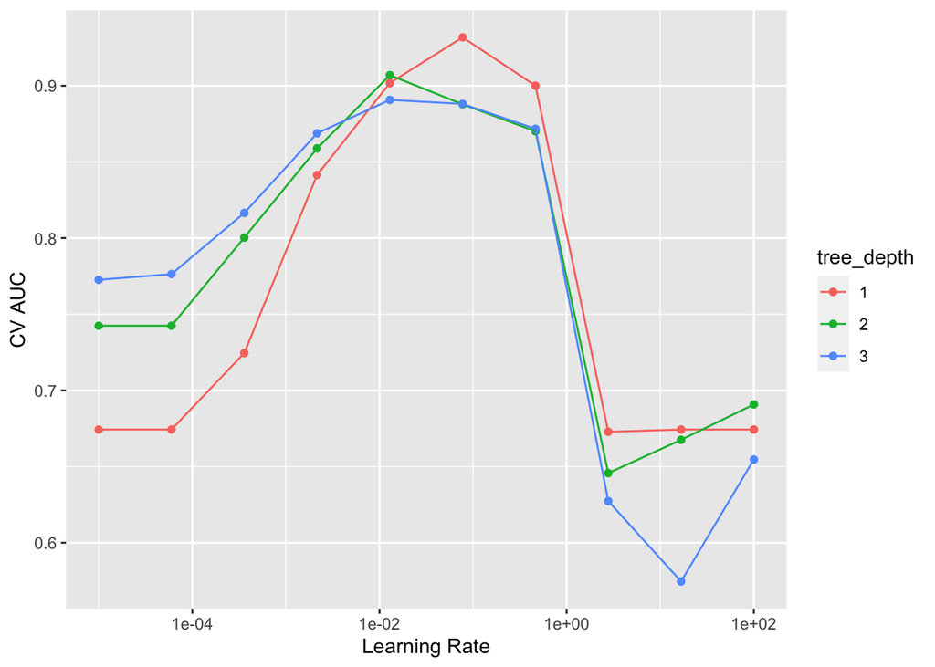

```r
classboost_fit %>%
  collect_metrics() %>%
  print(width = Inf) %>%
  filter(.metric == "roc_auc") %>%
  mutate(tree_depth = as.factor(tree_depth)) %>%
  ggplot(mapping = aes(x = learn_rate, y = mean, color = tree_depth)) +
  geom_point() +
  geom_line() +
  labs(x = "Learning Rate", y = "CV AUC") +
  scale_x_log10()
```

```r
classboost_fit %>%
  show_best("roc_auc")
```

```
# A tibble: 5 × 8
  tree_depth learn_rate .metric .estimator  mean     n std_err .config
       <int>      <dbl> <chr>   <chr>      <dbl> <int>   <dbl> <chr>
1          1     0.0774 roc_auc binary     0.932     5 0.0129  Preprocessor1_Mo…
2          2     0.0129 roc_auc binary     0.907     5 0.0118  Preprocessor1_Mo…
3          1     0.0129 roc_auc binary     0.902     5 0.0166  Preprocessor1_Mo…
4          1     0.464  roc_auc binary     0.900     5 0.00714 Preprocessor1_Mo…
5          3     0.0129 roc_auc binary     0.891     5 0.0121  Preprocessor1_Mo…
```

```r
best_classboost <- classboost_fit %>%
  select_best("roc_auc")
best_classboost
```

```
# A tibble: 1 × 3
  tree_depth learn_rate .config
       <int>      <dbl> <chr>
1          1     0.0774 Preprocessor1_Model16
```

```r
# Final workflow
final_wf_classboost <- classboost_wf %>%
  finalize_workflow(best_classboost)
final_wf_classboost
```

```
══ Workflow ════════════════════════════════════════════════════════════════════
Preprocessor: Recipe
Model: boost_tree()

── Preprocessor ────────────────────────────────────────────────────────────────
2 Recipe Steps

• step_dummy()
• step_zv()

── Model ───────────────────────────────────────────────────────────────────────
Boosted Tree Model Specification (classification)

Main Arguments:
  trees = 1000
  tree_depth = 1
  learn_rate = 0.0774263682681127

Computational engine: xgboost
```

```r
# Fit the whole training set, then predict the test cases
final_fit_classboost <-
  final_wf_classboost %>%
  last_fit(carseats_split)

# Test metrics
final_fit_classboost %>%
  collect_metrics()
```

```
# A tibble: 2 × 4
  .metric  .estimator .estimate .config
  <chr>    <chr>          <dbl> <chr>
1 accuracy binary         0.82  Preprocessor1_Model1
2 roc_auc  binary         0.907 Preprocessor1_Model1
```

```r
final_classboost <- extract_workflow(final_fit_classboost)
final_classboost
```

```
══ Workflow [trained] ══════════════════════════════════════════════════════════
Preprocessor: Recipe
Model: boost_tree()

── Preprocessor ────────────────────────────────────────────────────────────────
2 Recipe Steps

• step_dummy()
• step_zv()

── Model ───────────────────────────────────────────────────────────────────────
##### xgb.Booster
raw: 744.2 Kb
call:
  xgboost::xgb.train(params = list(eta = 0.0774263682681127, max_depth = 1L,
    gamma = 0, colsample_bytree = 1, colsample_bynode = 1, min_child_weight = 1,
    subsample = 1), data = x$data, nrounds = 1000, watchlist = x$watchlist,
    verbose = 0, nthread = 1, objective = "binary:logistic")
params (as set within xgb.train):
  eta = "0.0774263682681127", max_depth = "1", gamma = "0", colsample_bytree = "1", colsample_bynode = "1", min_child_weight = "1", subsample = "1", nthread = "1", objective = "binary:logistic", validate_parameters = "TRUE"
xgb.attributes:
  niter
callbacks:
  cb.evaluation.log()
# of features: 11
niter: 1000
nfeatures : 11
evaluation_log:
     iter training_logloss
    <num>            <num>
        1        0.6791108
        2        0.6670828
---
      999        0.1680932
     1000        0.1680208
```

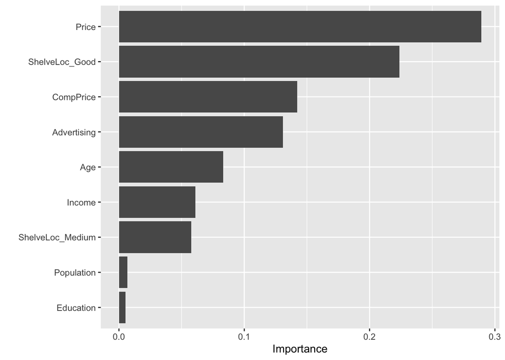

```r
final_classboost %>%
  extract_fit_parsnip() %>%
  vip()
```

The final boosting classification model has a ROC AUC of approximately 0.91 and an accuracy of 0.82. This classification model had the highest ROC AUC and accuracy values compared to the regression tree and random forest models. The ROC AUC value of 0.91 is an excellent value, implying that the model performs very well in terms of distinguishing between the two classes. The model was able to correctly classify 82% of the observations, which is a reasonably high accuracy score and indicates high predictive power.

### 5.4 Evaluate out-of-sample performance on a test set

The out-of-sample performance on the test set for the regression tree, random forest, and boosting models are as follows: - Regression Tree: ROC AUC = 0.81, Accuracy = 0.78 - Random Forest: ROC AUC = 0.89, Accuracy = 0.81 - Boosting: ROC AUC = 0.91, Accuracy = 0.82

In summary, the boosting classification model has the best performance in terms of ROC AUC and accuracy, followed by the random forest classification model, and then the regression tree classification model. This suggests that the boosting model is the best model for classifying sales as high or low in the Carseats data set.